# Regresión Lineal

Juan Sebastián González Pinilla

## Importar, limpiar y visualizar los datos

Nos basaremos en unos datos sobre el salario de personas de distintas nacionalidades, con diferentes edades. En este ejercicio nos basarémos únicamente del salario y la edad, la finalidad es predecir el salario que puede ganar una persona de 33, 60 y 25 años.

```r
library(readr)
```

```r
data = read_csv("Dia9.csv")
data
```

| Pais | Edad | Salario | Compra |
| --- | --- | --- | --- |
| France | 44 | 72000 | No |
| Spain | 27 | 48000 | Yes |
| Germany | 30 | 54000 | No |
| Spain | 38 | 61000 | No |
| Germany | 40 | NaN | Yes |
| France | 35 | 58000 | Yes |
| Spain | NaN | 52000 | No |
| France | 48 | 79000 | Yes |
| Germany | 50 | 83000 | No |
| France | 37 | 67000 | Yes |

```r
Edad=data$Edad;Edad
```

```
##  [1]  44  27  30  38  40  35 NaN  48  50  37
```

```r
Salario=data$Salario;Salario
```

```
##  [1] 72000 48000 54000 61000   NaN 58000 52000 79000 83000 67000
```

Creamos dos dataset nuevos con los NaN eliminados

```r
dataEdad=data[!is.na(data$Edad),]
dataSalario=data[!is.na(data$Salario),]
```

Reemplazamos los NaN del dataframe original con la media de los datos dataframe nuevos (porque no contienen el NaN)

```r
data$Edad[is.na(data$Edad)] = mean(dataEdad$Edad)
data$Salario[is.na(data$Salario)] = mean(dataSalario$Salario)
data
```

| Pais | Edad | Salario | Compra |
| --- | --- | --- | --- |
| France | 44.00000 | 72000.00 | No |
| Spain | 27.00000 | 48000.00 | Yes |
| Germany | 30.00000 | 54000.00 | No |
| Spain | 38.00000 | 61000.00 | No |
| Germany | 40.00000 | 63777.78 | Yes |
| France | 35.00000 | 58000.00 | Yes |
| Spain | 38.77778 | 52000.00 | No |
| France | 48.00000 | 79000.00 | Yes |
| Germany | 50.00000 | 83000.00 | No |
| France | 37.00000 | 67000.00 | Yes |

## Modelar la ecuación de Regresión

Modelar el salario por la variable edad

```r
lm_Sal_Ed = lm(Salario~Edad,data=data)
lm_Sal_Ed
```

```
##
## Call:
## lm(formula = Salario ~ Edad, data = data)
##
## Coefficients:
## (Intercept)         Edad
##        7362         1455
```

Visualizamos los valores y la curva del modelo de regresión lineal

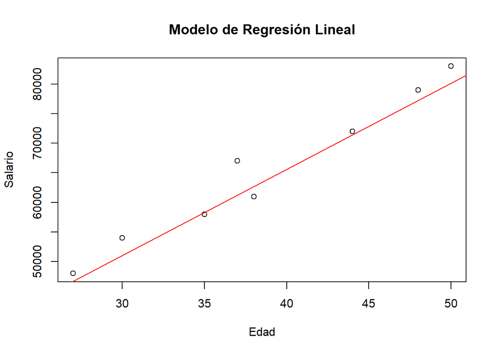

```r
plot(Edad,Salario,main="Modelo de Regresión Lineal")
abline(lm_Sal_Ed, col = "red")
```

## Predicción

Creamos un marco de datos invisible, que será el valor que vamos a predecir

```r
valor_predecir = data.frame(Edad = c(33,60,25));valor_predecir
```

| Edad |
| --- |
| 33 |
| 60 |
| 25 |

Predecirmos el valor creado con base en el modelo de regresión

```r
predict(lm_Sal_Ed, newdata = valor_predecir)
```

```
##        1        2        3
## 55372.00 94652.85 43733.23
```

### Conclusiones

Basado en el modelo lineal que se estimó a partir del conjunto de datos de `data`, se predijo que:

- El salario promedio para un trabajador de 33 años sería de alrededor de 55.372 dólares al año
- El salario promedio para un trabajador de 60 años sería de alrededor de 94.652,85 dólares al año
- El salario promedio para un trabajador de 25 años sería de alrededor de 43.733,23 dólares al año